# Categorical Summaries

Seth Harrison

2018-09-09 22:19:58

Consider the Flight Delays dataset discussed in Chapter 1 of the Chihara & Hesterberg textbook, which contains information on selected flights departing from LaGuardia airport in 2009. Complete the problems below using that dataset. For all plots, be sure to add an informative title and labels for the x and y axes.

```r
delays <- read.csv("https://raw.githubusercontent.com/STAT-JET-ASU/Datasets/master/Chihara/FlightDelays.csv")
library(dplyr)
library(ggplot2)
```

### Problem 1

Create frequency tables for all of the qualitative variables.

```r
carrierTable <- table(delays$Carrier)
destinationTable <- table(delays$Destination)
departTable <- table(delays$DepartTime)
daysTable <- table(delays$Day)
monthsTable <- table(delays$Month)
delayed30Table <- table(delays$Delayed30)
```

### Problem 2

Create a barplot to display the frequency of each destination.

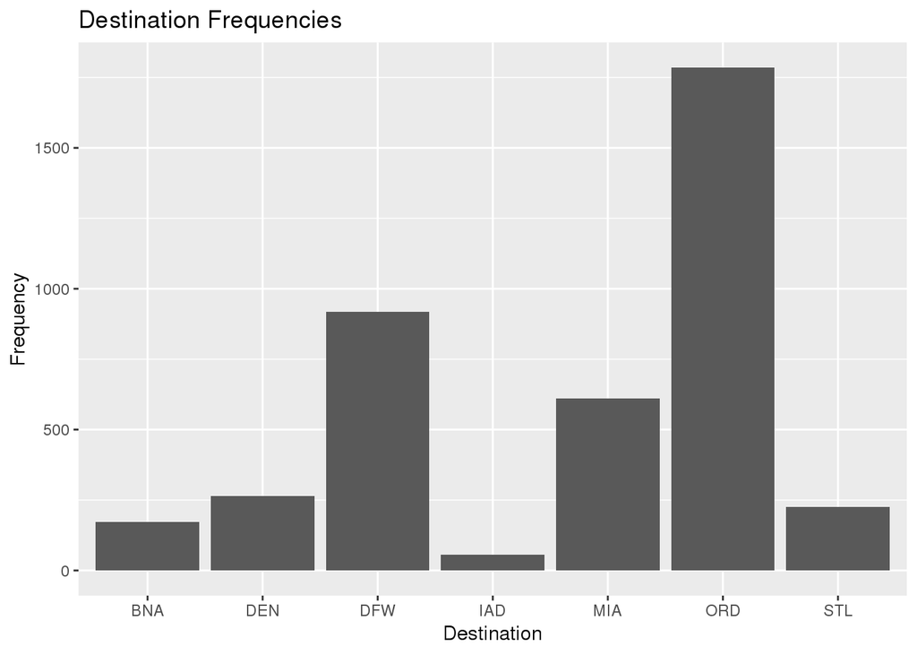

```r
ggplot(delays, aes(x = Destination)) + geom_bar() + labs(title = "Destination Frequencies", y = "Frequency")
```

### Problem 3

Create a barplot to show the relative frequency of each destination.

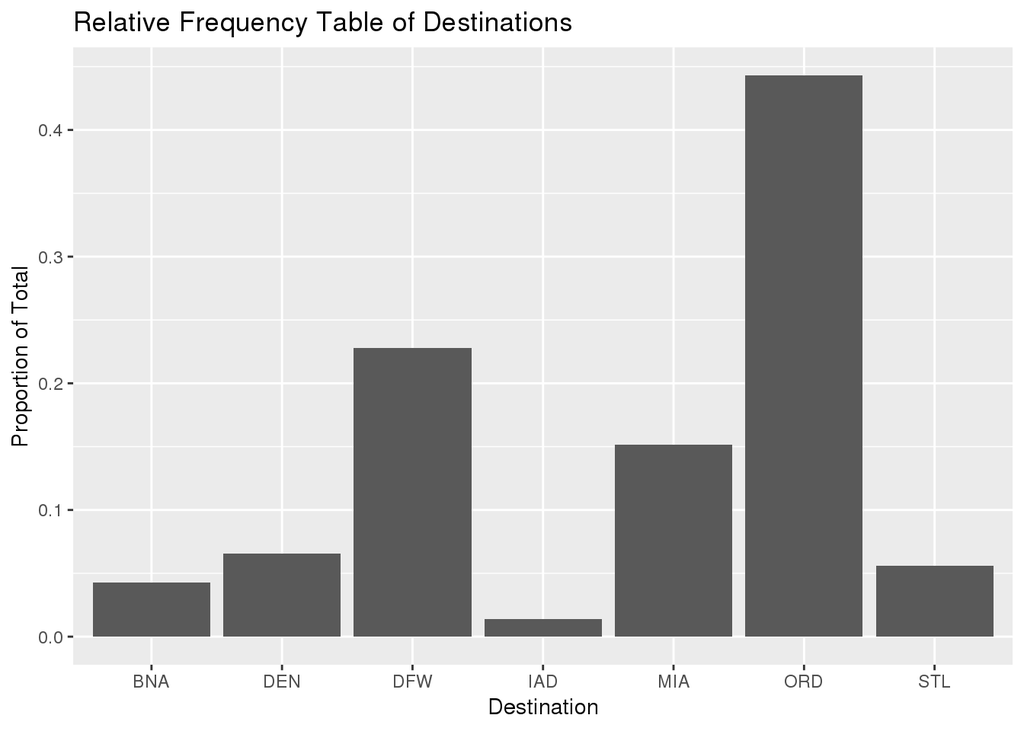

```r
delaysTable <- delays %>%
  count(Destination) %>%
  mutate(cum_n    = cumsum(n),
         prop     = prop.table(n))
ggplot(delaysTable, aes(x = Destination, y = prop)) +
  geom_col() +
  labs(y = "Proportion of Total") +
  ggtitle("Relative Frequency Table of Destinations")
```